# **MScFE 642 DEEP LEARNING FOR FINANCE**

## **Group Work Project** # 1

### **Student Group** 8422

### *Yesheng Huang, Atakan Devrent, Mukiza Rayner*

In this project, we are aiming to analyze daily prices of the TSLA stock for the last 3 years. Then, we are going to build an **MLP** using the **PyTorch** framework to predict both the prices and log returns of the stock, separately. As our last work, we are going to transform our time series data for **Gramian Angular Field** representation and try to predict the prices and log returns of the stock using **Convolutional Neural Networks**.

## **Step 1**

### a) **Picking a time series - Tesla Inc (TSLA)**

In this step we'll exploring Tesla Stock prices from **2022** to **2025**

```python
# Import necessary libraries
import numpy as np
import pandas as pd
from matplotlib import pyplot as plt
import yfinance as yf
from datetime import date, timedelta
import statsmodels
import scipy.stats as stats
import torch
from torch import nn
import torchinfo
```

We first download our data and select only the **Adj Close** column for daily close prices. Then, we generate log returns to make the time series stationary for step 1 (b)

```python
end_date = date(2025, 2, 10)
start_date = date(2022, 2, 10)
ticker = "TSLA"

# Get the data
tsla =yf.Ticker(ticker)
data = tsla.history(
        start=start_date,
        end=end_date,
        auto_adjust=False
    )

# Generate log returns
data["logr"] = data["Adj Close"].apply(np.log).diff()
data.dropna(inplace=True)

# Drop extra columns
data = data.loc[:, ["Adj Close", "logr"]]
```

#### **Visual Exploration of the Time series**

Here we would like to visualize the data to get a visual sense of the price evolution

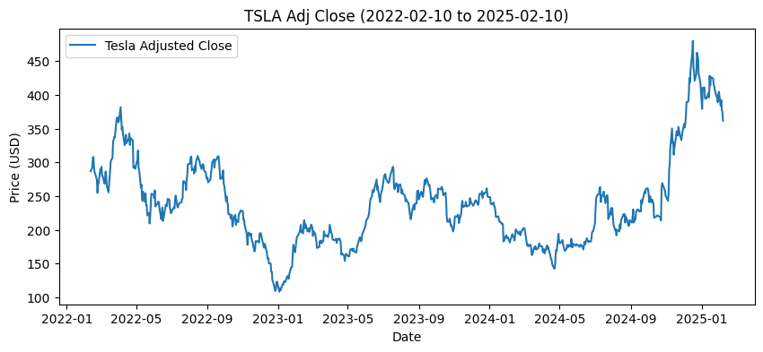

```python
%matplotlib inline
plt.figure(figsize=(10, 4))
plt.plot(data['Adj Close'], label="Tesla Adjusted Close")
plt.title(f'{ticker} Adj Close ({start_date} to {end_date})')
plt.xlabel('Date')
plt.ylabel('Price (USD)')
plt.legend()
plt.show()
```

#### **Summary Statistics**

```python
from scipy.stats import skew, kurtosis

print("Summary Statistics:")
display(data['Adj Close'].describe())

# Skew and Kurtosis
print("\nSkew and Kurtosis:")
print(f"Skewness: {skew(data['Adj Close'])}")
print(f"Kurtosis: {kurtosis(data['Adj Close'])}")
```

```
Summary Statistics:
```

```
count    750.000000
mean     239.115973
std       65.606099
min      108.099998
25%      189.664997
50%      233.068336
75%      267.203331
max      479.859985
Name: Adj Close, dtype: float64
```

```
Skew and Kurtosis:
Skewness: 0.9727156659519174
Kurtosis: 1.07505343780283
```

#### **Distribution Analysis**

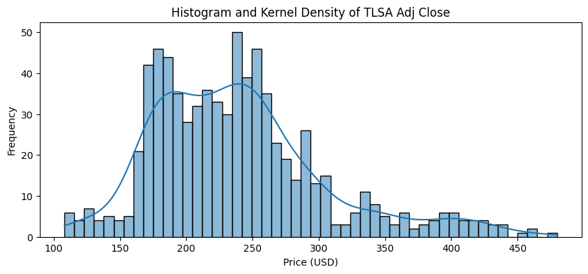

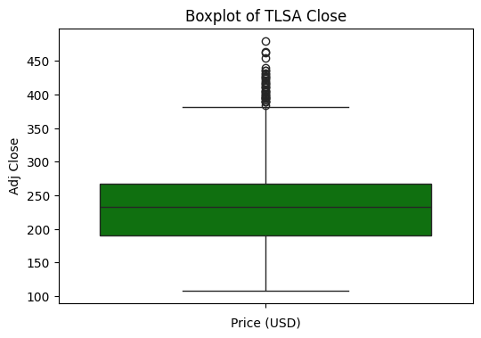

```python
import seaborn as sns


# Histogram and KDE
plt.figure(figsize=(10, 4))
sns.histplot(
    data=data['Adj Close'].dropna(),
    kde=True,
    bins=50
)
plt.title('Histogram and Kernel Density of TLSA Adj Close')
plt.xlabel('Price (USD)')
plt.ylabel('Frequency')
plt.show()

# Boxplot to check for outliers
plt.figure(figsize=(6,4))
sns.boxplot(
    data=data['Adj Close'].dropna(),
    color='green'
)
plt.title('Boxplot of TLSA Close')
plt.xlabel('Price (USD)')
plt.show()
```

- From the histogram and kernel density plot, we can see that Tesla’s Adjusted Close prices are right-skewed. This asymmetry aligns with the positive skew and kurtosis we noted earlier
- The boxplot reaffirms these observations: it shows a relatively tight interquartile range around the median (approximately 230), but a noticeable cluster of “outlier” points stretching above 350.

#### **Stationarity Tests**

```python
from statsmodels.tsa.stattools import adfuller

def adf_test(series):
    print(f'Augmented Dickey-Fuller Test')
    result = adfuller(series.dropna(),autolag='AIC')
    labels = ['ADF Test Statistic', 'p-values', 'Number of Lags Used', 'Number of Observations Used']
    out = dict(zip(labels, result[0:4]))

    for key, val in out.items():
        print(f"    {key}:{val}")

    for key, val in result[4].items():
        print(f"   Critical Value {key}:{val}")

    print("-"*40)


adf_test(data['Adj Close'])
```

```
Augmented Dickey-Fuller Test
    ADF Test Statistic:-2.0346891265095994
    p-values:0.2715732280816856
    Number of Lags Used:10
    Number of Observations Used:739
   Critical Value 1%:-3.439229783394421
   Critical Value 5%:-2.86545894814762
   Critical Value 10%:-2.5688568756191392
----------------------------------------
```

The Augmented Dickey-Fuller (ADF) test suggests that we cannot reject the null hypothesis of a unit root—in and the time series is likely non‐stationary.

This is because the test statistic does not fall below the critical values, and the p‐value is not low enough, the result implies that Tesla’s adjusted closing prices exhibit non‐stationary behavior over this period. This is consistent with our earlier observations that the mean and variance change over time, reinforcing the idea that standard stationarity assumptions do not hold.

#### **Autocorrelation and Partial Autocorrelation**

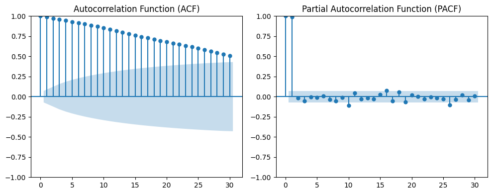

```python
from statsmodels.graphics.tsaplots import plot_acf, plot_pacf

# Autocorrelation & Partial Autocorrelation
plt.figure(figsize=(10, 4))

plt.subplot(1,2,1)
plot_acf(data['Adj Close'].dropna(), ax=plt.gca(), lags=30)
plt.title('Autocorrelation Function (ACF)')

plt.subplot(1,2,2)
plot_pacf(data['Adj Close'].dropna(), ax=plt.gca(), lags=30,method='ywm')
plt.title('Partial Autocorrelation Function (PACF)')

plt.tight_layout()
plt.show()
```

These ACF and PACF plots provide further evidence of non‐stationarity and persistent autocorrelation in Tesla’s Adjusted Close prices:

- ACF (Autocorrelation Function): The very slow decay of the autocorrelation values *(staying well above zero for numerous lags)* shows non‐stationarity.
- PACF (Partial Autocorrelation Function): The first two lags are notably significant, after which the plot settles around zero. This pattern exhibits strong memory from one period to the next.

Combined with the ADF test result, these plots reinforce the conclusion that the series is not stationary.

### **(b) Perform the same analysis for a transformed version of the time series**

*Here we will take the log transform and first difference of the series to make it approximately stationary*

#### **Visualizing Log-Returns series**

```python
log_returns = data["logr"]
```

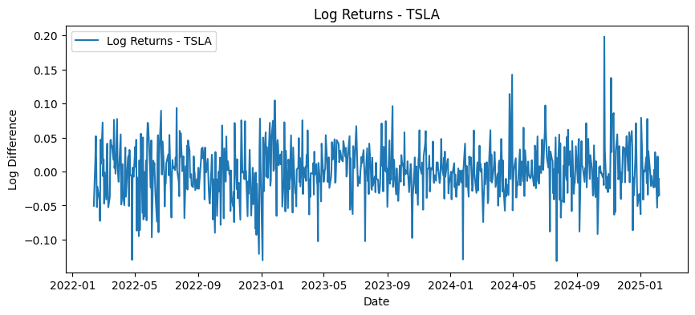

```python
plt.figure(figsize=(10,4))
plt.plot(data["logr"], label="Log Returns - TSLA")
plt.title('Log Returns - TSLA')
plt.xlabel('Date')
plt.ylabel('Log Difference')
plt.legend()
plt.show()
```

In contrast to the raw price series, the log returns (log-differences) fluctuate around zero with no clear upward or downward trend, indicating a more stationary process.

#### **Summary statistics of the log returns**

```python
print("Summary Statistics for Log-Returns Series:")
display(data['logr'].describe())

print(f"Skewness: {skew(data['logr'])}")
print(f"Kurtosis: {kurtosis(data['logr'])}")
```

```
Summary Statistics for Log-Returns Series:
```

```
count    750.000000
mean       0.000242
std        0.038236
min       -0.131643
25%       -0.020557
50%        0.001031
75%        0.020897
max        0.198187
Name: logr, dtype: float64
```

```
Skewness: 0.048182585081621036
Kurtosis: 1.7891042416850107
```

- The near‐zero skewness (0.048) indicates a much more symmetrical distribution of returns, unlike the positively skewed raw price distribution.
- The log returns still have high kurtosis (fatter tails), reflecting occasional extreme price swings
- The relatively small standard deviation (~0.038) indicates fluctuations are more modest (in percentage terms) compared to swings in the raw price

#### **Distribution Analysis of Log Returns Series**

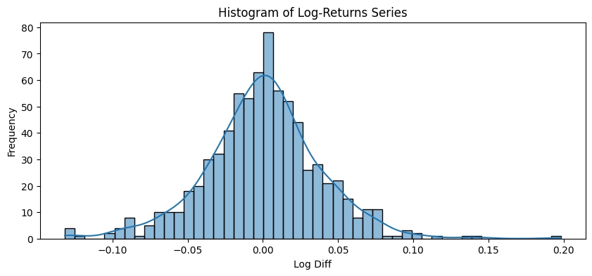

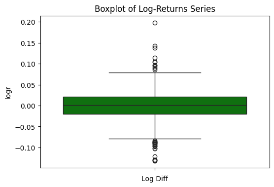

```python
plt.figure(figsize=(10,4))
sns.histplot(data['logr'], kde=True, bins=50)
plt.title('Histogram of Log-Returns Series')
plt.xlabel('Log Diff')
plt.ylabel('Frequency')
plt.show()


plt.figure(figsize=(6, 4))
sns.boxplot(data=data['logr'],color='green' )
plt.title('Boxplot of Log-Returns Series')
plt.xlabel('Log Diff')
plt.show()
```

**Test for normality**

```python
stat, p_value = stats.shapiro(data['logr'])
print("Shapiro-Wilk Test (log returns)")
print(f"Test Statistic: {stat:.4f}, p-value: {p_value:.4g}")
```

```
Shapiro-Wilk Test (log returns)
Test Statistic: 0.9817, p-value: 4.368e-08
```

- The **histogram and boxplot** of log returns both suggest a roughly bell‐shaped distribution centered near zero. However, it’s clear from the tails and outliers that the distribution still deviates from a perfect normal shape
- Shapiro‐Wilk Test test statistic (0.9817) with a very low p‐value suggests we **reject** the null hypothesis of perfect normality.
- This aligns with higher kurtosis (fat tails) and the presence of outliers.

#### **Stationarity Tests of Log Returns Series**

```python
adf_test(data['logr'])
```

```
Augmented Dickey-Fuller Test
    ADF Test Statistic:-7.562219130805776
    p-values:2.989237807737757e-11
    Number of Lags Used:9
    Number of Observations Used:740
   Critical Value 1%:-3.4392177416762086
   Critical Value 5%:-2.8654536415414684
   Critical Value 10%:-2.5688540485756026
----------------------------------------
```

The Augmented Dickey‐Fuller Test on the log‐return series strongly indicates stationarity.

Because the test statistic is more negative than each of the critical values—and the p‐value is well under the threshold 0.05; we can reject the null hypothesis (that the series has a unit root).

#### **Autocorrelation and Partial Autocorrelation of Log Returns Series**

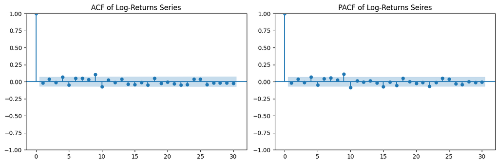

```python
plt.figure(figsize=(12, 4))

plt.subplot(1,2,1)
plot_acf(data['logr'].dropna(), ax=plt.gca(), lags=30)
plt.title('ACF of Log-Returns Series')

plt.subplot(1,2,2)
plot_pacf(data['logr'].dropna(), ax=plt.gca(), lags=30, method='ywm')
plt.title('PACF of Log-Returns Seires')

plt.tight_layout()
plt.show()
```

ACF and PACF plots for the log‐return series both show little to no significant autocorrelation beyond lag 0

#### **c) Use fractional differencing to obtain a new version of the time series that is stationary but retains relevant information about the data.**

Source: https://www.kaggle.com/code/elvisesp/time-series-analysis-using-fractional-differencing/notebook

```python
def getWeights(d,lags):
    # return the weights from the series expansion of the differencing operator
    # for real orders d and up to lags coefficients
    w=[1]
    for k in range(1,lags):
        w.append(-w[-1]*((d-k+1))/k)
    w=np.array(w).reshape(-1,1)
    return w

def ts_differencing(series, order, lag_cutoff):
    # return the time series resulting from (fractional) differencing
    # for real orders order up to lag_cutoff coefficients

    weights=getWeights(order, lag_cutoff)
    res=0
    for k in range(lag_cutoff):
        res += weights[k]*series.shift(k).fillna(0)
    return res[lag_cutoff:]

def optimize_d(series, lags, p_value=0.05):
    # optimize the order of differencing for a given range of lags
    best_d = 0
    best_adf_p = np.inf
    for d in np.linspace(0, 1, 21):
        diff_series = ts_differencing(series, d, lags)
        adf_p = adfuller(diff_series)[1]
        if adf_p < p_value:
            best_adf_p = adf_p
            best_d = d
            print(f"Found d: {best_d}, ADF p-value: {best_adf_p}")
            return best_d

optimum_d = optimize_d(data["Adj Close"], 10)
```

```
Found d: 0.5, ADF p-value: 0.02651015887061332
```

After we have found the optimum $d$ parameter, we create the fractional time series and describe its properties and distribution:

```python
frac_prices = ts_differencing(data["Adj Close"], optimum_d, 10)
print(frac_prices)
```

```
Date
2022-02-28 00:00:00-05:00    69.213429
2022-03-01 00:00:00-05:00    57.238531
2022-03-02 00:00:00-05:00    61.302869
2022-03-03 00:00:00-05:00    44.559445
2022-03-04 00:00:00-05:00    49.883710
                               ...
2025-02-03 00:00:00-05:00    55.572162
2025-02-04 00:00:00-05:00    74.069227
2025-02-05 00:00:00-05:00    58.156741
2025-02-06 00:00:00-05:00    61.449477
2025-02-07 00:00:00-05:00    52.601559
Name: Adj Close, Length: 740, dtype: float64
```

#### **Visualizaing Fractional-differenced series**

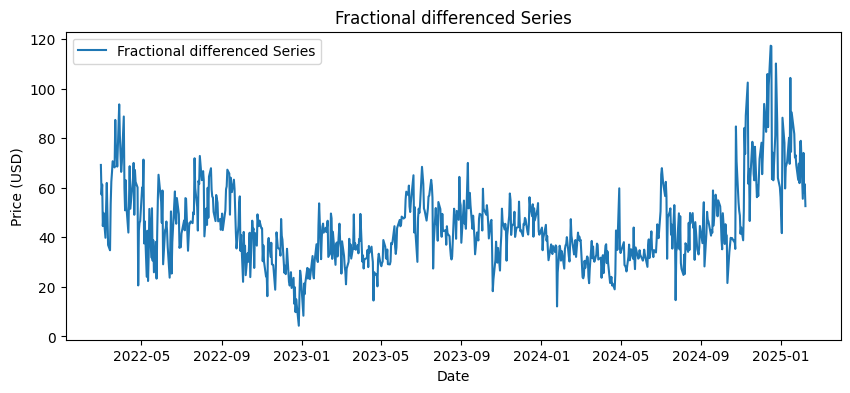

```python
plt.figure(figsize=(10, 4))
plt.plot(frac_prices, label="Fractional differenced Series")
plt.title('Fractional differenced Series')
plt.xlabel('Date')
plt.ylabel('Price (USD)')
plt.legend()
plt.show()
```

The fractionally differenced series looks less trend-dominated than the raw prices yet still retains more of its long-term pattern than the log returns series.

#### **Summary statistics of the Fractional Differenced series**

```python
print("Summary Statistics for Fractional-Differenced Series:")
display(frac_prices.describe())

print(f"Skewness: {skew(frac_prices)}")
print(f"Kurtosis: {kurtosis(frac_prices)}")
```

```
Summary Statistics for Fractional-Differenced Series:
```

```
count    740.000000
mean      44.465809
std       16.013025
min        4.347030
25%       33.549346
50%       42.153729
75%       51.919070
max      117.316581
Name: Adj Close, dtype: float64
```

```
Skewness: 1.0555690487575637
Kurtosis: 2.017826365764911
```

#### **Distribution Analysis of Fractional differenced Series**

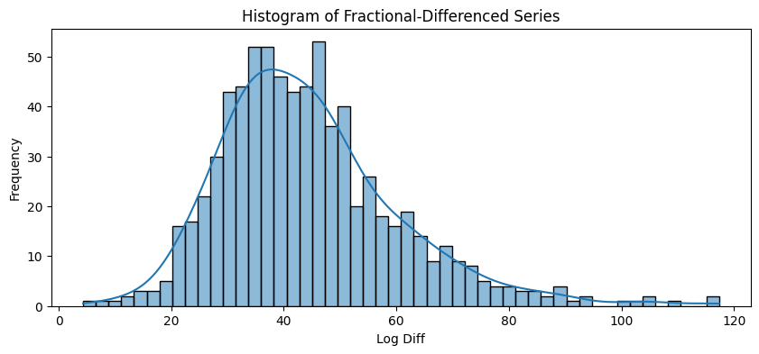

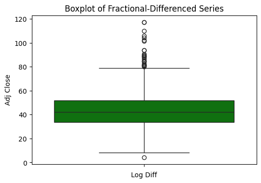

```python
plt.figure(figsize=(10,4))
sns.histplot(frac_prices, kde=True, bins=50)
plt.title('Histogram of Fractional-Differenced Series')
plt.xlabel('Log Diff')
plt.ylabel('Frequency')
plt.show()


plt.figure(figsize=(6, 4))
sns.boxplot(data=frac_prices,color='green')
plt.title('Boxplot of Fractional-Differenced Series')
plt.xlabel('Log Diff')
plt.show()
```

```python
stat, p_value = stats.shapiro(frac_prices)
print("Shapiro-Wilk Test")
print(f"Test Statistic: {stat:.4f}, p-value: {p_value:.4g}")
```

```
Shapiro-Wilk Test
Test Statistic: 0.9459, p-value: 8.356e-16
```

The histogram, boxplot, and Shapiro‐Wilk test are consistent with the summary statistics for the fractional differenced series. The histogram’s right tail and the boxplot’s cluster of outliers in the upper range agree with the skewness value (> 0)

The boxplot shows numerous “outliers” above the interquartile range, aligning with the kurtosis value (> 1) that indicates heavier‐than‐normal tails.

The Shapiro‐Wilk test p‐value (very small) reaffirms we should reject normality, echoing the elevated skewness and kurtosis values.

#### **Stationarity Tests of Fractional differenced Series**

```python
adf_test(frac_prices)
```

```
Augmented Dickey-Fuller Test
    ADF Test Statistic:-3.1005818508546787
    p-values:0.02651015887061332
    Number of Lags Used:10
    Number of Observations Used:729
   Critical Value 1%:-3.4393520240470554
   Critical Value 5%:-2.8655128165959236
   Critical Value 10%:-2.5688855736949163
----------------------------------------
```

Based on the Augmented Dickey-Fuller (ADF) results,We have strong evidence (p~0.026) that the fractionally differenced series is stationary.

Since the test statistic exceeds the 1% critical value (i.e., -3.10 is not quite as negative as -3.44) but is below the 5% critical value (-2.87), we can reject the null hypothesis of a unit root at the 5% level, indicating stationarity at that significance threshold.

#### **Autocorrelation and Partial Autocorrelation of Fractional differenced Series**

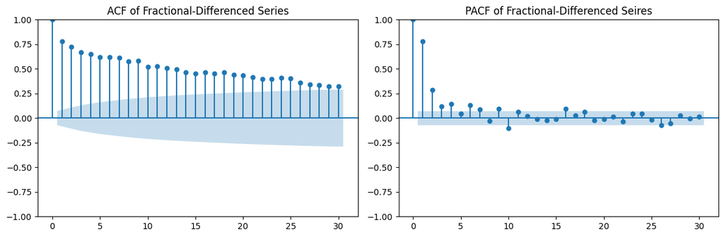

```python
plt.figure(figsize=(12, 4))

plt.subplot(1,2,1)
plot_acf(frac_prices.dropna(), ax=plt.gca(), lags=30)
plt.title('ACF of Fractional-Differenced Series')

plt.subplot(1,2,2)
plot_pacf(frac_prices.dropna(), ax=plt.gca(), lags=30, method='ywm')
plt.title('PACF of Fractional-Differenced Seires')

plt.tight_layout()
plt.show()
```

The ACF and PACF plots reflect that we've partially removed the unit root but still retained some of the long-memory. This is evident in the steadily declining ACF and a PACF that doesn't go to zero after the first difference, as it might in a purely short-memory or in an integer differencing scenario.

## Step 2

In *Step 2*, we are going to develop a Multi-Layer Perceptron (MLP) to predict our time series that we got in Step 1: **prices** and **log returns**.

We are going to use the N-BEATS architecture by *Boris N. Oreshkin, Dmitri Carpov, Nicolas Chapados, Yoshua Bengio*, which has proven immense success in prediction problems in univariate time series domain. N-BEATS is a powerful deep learning architecture for time series forecasting because it leverages a simple-to-understand but highly expressive fully connected network without reliance on time-series-specific feature engineering. Its block-based structure, where each block provides both a backcast and a forecast, allows iterative residual learning that improves the prediction increasingly in each iteration. The doubly residual stacking of the novel architecture can propagate gradients successfully and allows the model to decompose the input signal into significant components, such as trend and seasonality, without sacrificing performance. All this is achieved with flexibility, interpretability, and state-of-the-art accuracy on a broad variety of forecasting benchmarks, which makes N-BEATS a compelling choice for time series analysis.

(Reference: https://arxiv.org/abs/1905.10437 - *N-BEATS: Neural basis expansion analysis for interpretable time series forecasting, Boris N. Oreshkin, Dmitri Carpov, Nicolas Chapados, Yoshua Bengio*)

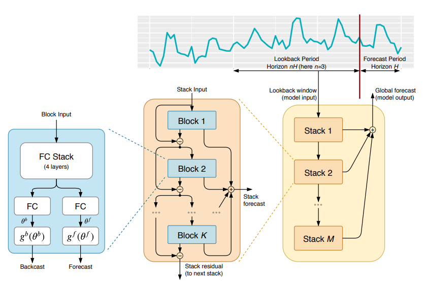

(Reference: https://arxiv.org/abs/1905.10437 - *N-BEATS: Neural basis expansion analysis for interpretable time series forecasting, Boris N. Oreshkin, Dmitri Carpov, Nicolas Chapados, Yoshua Bengio*)

We first develop the **Block** part of the architecture. We use multiples of $256$ for the hyperparameters of the intermediate layers, as hyperparameter optimization is beyond the scope of this work.

Moreover, we use **Dropout** regularization for intermediate layers, to achieve generalization of our model.

```python
class NBEATSBlock(nn.Module):
    def __init__(self, H, n, dropout_prob=0.1):
        """
        Parameters:
        H (int): Forecast horizon (number of future time steps to predict)
        n (int): How many times the forecast horizon to look back
        """
        super().__init__()
        self.stem = nn.Sequential(  # input size: (batch_size, 1, H*n)
            nn.Linear(in_features=H*n, out_features=512), nn.ReLU(), nn.Dropout(dropout_prob),
            nn.Linear(in_features=512, out_features=1024), nn.ReLU(), nn.Dropout(dropout_prob),
            nn.Linear(in_features=1024, out_features=512), nn.ReLU(), nn.Dropout(dropout_prob),
            nn.Linear(in_features=512, out_features=256), nn.ReLU()
        )

        # In generic architecture, the backcast and forecast transformations are just linear layers
        self.backcast = nn.Linear(in_features=256, out_features=H*n)
        self.forecast = nn.Linear(in_features=256, out_features=H)

    def forward(self, x):
        x = self.stem(x)
        x_bc = self.backcast(x)
        x_fc = self.forecast(x)

        return x_bc, x_fc
```

```python
H = 10  # Forecast horizon
n = 5  # Look back n times the forecast horizon

model = NBEATSBlock(H, n)
model.to("cuda")
torchinfo.summary(model, input_size=(1, H*n))
```

```
==========================================================================================
Layer (type:depth-idx)                   Output Shape              Param #
==========================================================================================
NBEATSBlock                              [1, 50]                   --
├─Sequential: 1-1                        [1, 256]                  --
│    └─Linear: 2-1                       [1, 512]                  26,112
│    └─ReLU: 2-2                         [1, 512]                  --
│    └─Dropout: 2-3                      [1, 512]                  --
│    └─Linear: 2-4                       [1, 1024]                 525,312
│    └─ReLU: 2-5                         [1, 1024]                 --
│    └─Dropout: 2-6                      [1, 1024]                 --
│    └─Linear: 2-7                       [1, 512]                  524,800
│    └─ReLU: 2-8                         [1, 512]                  --
│    └─Dropout: 2-9                      [1, 512]                  --
│    └─Linear: 2-10                      [1, 256]                  131,328
│    └─ReLU: 2-11                        [1, 256]                  --
├─Linear: 1-2                            [1, 50]                   12,850
├─Linear: 1-3                            [1, 10]                   2,570
==========================================================================================
Total params: 1,222,972
Trainable params: 1,222,972
Non-trainable params: 0
Total mult-adds (Units.MEGABYTES): 1.22
==========================================================================================
Input size (MB): 0.00
Forward/backward pass size (MB): 0.02
Params size (MB): 4.89
Estimated Total Size (MB): 4.91
==========================================================================================
```

Then, we develop the **Stack** part of the architecture, using our Blocks. *nn.Sequential* is designed to compose modules in a highly linear, feed-forward manner where the output of one module is automatically passed on as the input for the next. Because our **NBEATSStack** contains blocks that produce two outputs (*forecast* and *backcast*), we need to manually update the residual by subtracting the backcast from the input before passing it to the next block. This kind of custom control flow and multiple outputs handling is impossible with *nn.Sequential*, thus we use the class *nn.ModuleList*.

```python
class NBEATSStack(nn.Module):
    def __init__(self, K, H, n):
        """
        Parameters:
        K (int): Number of blocks in the stack
        H (int): Forecast horizon (number of future time steps to predict)
        n (int): How many times the forecast horizon to look back
        """
        super().__init__()
        self.blocks = nn.ModuleList([NBEATSBlock(H, n) for _ in range(K)])

    def forward(self, x):
        x_fc_sum = torch.zeros(x.size(0), H, dtype=x.dtype).to(x.device)
        residual = x  # start with the original input
        for block in self.blocks:
            x_bc, x_fc = block(residual)
            residual = residual - x_bc  # update residual using the block’s input
            x_fc_sum += x_fc
        return residual, x_fc_sum
```

```python
H = 10  # Forecast horizon
n = 5  # Look back n times the forecast horizon
K = 30  # Number of blocks in the stack

model = NBEATSStack(K, H, n)
model.to("cuda")
torchinfo.summary(model, input_size=(1, H*n))
```

```
==========================================================================================
Layer (type:depth-idx)                   Output Shape              Param #
==========================================================================================
NBEATSStack                              [1, 50]                   --
├─ModuleList: 1-1                        --                        --
│    └─NBEATSBlock: 2-1                  [1, 50]                   --
│    │    └─Sequential: 3-1              [1, 256]                  1,207,552
│    │    └─Linear: 3-2                  [1, 50]                   12,850
│    │    └─Linear: 3-3                  [1, 10]                   2,570
│    └─NBEATSBlock: 2-2                  [1, 50]                   --
│    │    └─Sequential: 3-4              [1, 256]                  1,207,552
│    │    └─Linear: 3-5                  [1, 50]                   12,850
│    │    └─Linear: 3-6                  [1, 10]                   2,570
│    └─NBEATSBlock: 2-3                  [1, 50]                   --
│    │    └─Sequential: 3-7              [1, 256]                  1,207,552
│    │    └─Linear: 3-8                  [1, 50]                   12,850
│    │    └─Linear: 3-9                  [1, 10]                   2,570
│    └─NBEATSBlock: 2-4                  [1, 50]                   --
│    │    └─Sequential: 3-10             [1, 256]                  1,207,552
│    │    └─Linear: 3-11                 [1, 50]                   12,850
│    │    └─Linear: 3-12                 [1, 10]                   2,570
│    └─NBEATSBlock: 2-5                  [1, 50]                   --
│    │    └─Sequential: 3-13             [1, 256]                  1,207,552
│    │    └─Linear: 3-14                 [1, 50]                   12,850
│    │    └─Linear: 3-15                 [1, 10]                   2,570
│    └─NBEATSBlock: 2-6                  [1, 50]                   --
│    │    └─Sequential: 3-16             [1, 256]                  1,207,552
│    │    └─Linear: 3-17                 [1, 50]                   12,850
│    │    └─Linear: 3-18                 [1, 10]                   2,570
│    └─NBEATSBlock: 2-7                  [1, 50]                   --
│    │    └─Sequential: 3-19             [1, 256]                  1,207,552
│    │    └─Linear: 3-20                 [1, 50]                   12,850
│    │    └─Linear: 3-21                 [1, 10]                   2,570
│    └─NBEATSBlock: 2-8                  [1, 50]                   --
│    │    └─Sequential: 3-22             [1, 256]                  1,207,552
│    │    └─Linear: 3-23                 [1, 50]                   12,850
│    │    └─Linear: 3-24                 [1, 10]                   2,570
│    └─NBEATSBlock: 2-9                  [1, 50]                   --
│    │    └─Sequential: 3-25             [1, 256]                  1,207,552
│    │    └─Linear: 3-26                 [1, 50]                   12,850
```

[output cut: 81 more lines]

```
│    └─NBEATSBlock: 2-30                 [1, 50]                   --
│    │    └─Sequential: 3-88             [1, 256]                  1,207,552
│    │    └─Linear: 3-89                 [1, 50]                   12,850
│    │    └─Linear: 3-90                 [1, 10]                   2,570
==========================================================================================
Total params: 36,689,160
Trainable params: 36,689,160
Non-trainable params: 0
Total mult-adds (Units.MEGABYTES): 36.69
==========================================================================================
Input size (MB): 0.00
Forward/backward pass size (MB): 0.57
Params size (MB): 146.76
Estimated Total Size (MB): 147.32
==========================================================================================
```

Finally, we develop the highest level of the hierarcy; putting individuals stacks on top of each other to finalize our network architecture:

```python
class NBEATS(nn.Module):
    def __init__(self, M, K, H, n):
        """
        Parameters:
        M (int): Number of stacks in the network
        K (int): Number of blocks in the stack
        H (int): Forecast horizon (number of future time steps to predict)
        n (int): How many times the forecast horizon to look back
        """
        super().__init__()
        self.H = H
        self.stacks = nn.ModuleList([NBEATSStack(K, H, n) for _ in range(M)])

    def forward(self, x):
        # Initialize forecast accumulator
        forecast_total = torch.zeros(x.size(0), self.H,
                                  device=x.device, dtype=x.dtype)
        residual = x

        for stack in self.stacks:
            # Process through stack
            residual, stack_forecast = stack(residual)
            # Aggregate forecasts
            forecast_total += stack_forecast

        return forecast_total
```

```python
M = 3 # Number of stacks in the network
H = 10  # Forecast horizon
n = 5  # Look back n times the forecast horizon
K = 30  # Number of blocks in the stack

model = NBEATS(M, K, H, n)
model.to("cuda")
torchinfo.summary(model, input_size=(1, H*n))
```

```
===============================================================================================
Layer (type:depth-idx)                        Output Shape              Param #
===============================================================================================
NBEATS                                        [1, 10]                   --
├─ModuleList: 1-1                             --                        --
│    └─NBEATSStack: 2-1                       [1, 50]                   --
│    │    └─ModuleList: 3-1                   --                        36,689,160
│    └─NBEATSStack: 2-2                       [1, 50]                   --
│    │    └─ModuleList: 3-2                   --                        36,689,160
│    └─NBEATSStack: 2-3                       [1, 50]                   --
│    │    └─ModuleList: 3-3                   --                        36,689,160
===============================================================================================
Total params: 110,067,480
Trainable params: 110,067,480
Non-trainable params: 0
Total mult-adds (Units.MEGABYTES): 110.07
===============================================================================================
Input size (MB): 0.00
Forward/backward pass size (MB): 1.70
Params size (MB): 440.27
Estimated Total Size (MB): 441.97
===============================================================================================
```

Now, we advance to the training part. Because our model has more than 100 million parameters, it is pretty data-hungry, so for training and validation we increase our data size and download TSLA price data between the years $2012 - 2022$ as our train/validation split. Then, the last 3 years of data is going to be a complete test set, which is the same data as the plotted data in Step 1.

```python
end_date = date(2022, 2, 10)
start_date = date(2012, 2, 10)
ticker = "TSLA"

trainval_data = yf.download(ticker, start_date, end_date)

end_date = date(2025, 2, 10)
start_date = date(2022, 2, 10)
test_data = yf.download(ticker, start_date, end_date)

trainval_data = trainval_data.droplevel(1, axis=1)
test_data = test_data.droplevel(1, axis=1)

# Generate log returns
trainval_data["logr"] = trainval_data["Close"].apply(np.log).diff()
trainval_data.dropna(inplace=True)

test_data["logr"] = test_data["Close"].apply(np.log).diff()
test_data.dropna(inplace=True)

# Drop extra columns
trainval_data = trainval_data.loc[:, ["Close", "logr"]]
test_data = test_data.loc[:, ["Close", "logr"]]

print()
print("-"*50)
print()
print("Train/Validation Data")
print(trainval_data.info())
print()
print(trainval_data.tail(5))
print()
print("-"*50)
print()
print("Test Data")
print(test_data.info())
print()
print(test_data.tail(5))
print()
```

```
[*********************100%***********************]  1 of 1 completed
[*********************100%***********************]  1 of 1 completed
```

```
--------------------------------------------------

Train/Validation Data
<class 'pandas.core.frame.DataFrame'>
DatetimeIndex: 2516 entries, 2012-02-13 to 2022-02-09
Data columns (total 2 columns):
 #   Column  Non-Null Count  Dtype
---  ------  --------------  -----
 0   Close   2516 non-null   float64
 1   logr    2516 non-null   float64
dtypes: float64(2)
memory usage: 59.0 KB
None

Price            Close      logr
Date
2022-02-03  297.046661 -0.016162
2022-02-04  307.773346  0.035474
2022-02-07  302.446655 -0.017459
2022-02-08  307.333344  0.016028
2022-02-09  310.666656  0.010788

--------------------------------------------------

Test Data
<class 'pandas.core.frame.DataFrame'>
DatetimeIndex: 750 entries, 2022-02-11 to 2025-02-07
Data columns (total 2 columns):
 #   Column  Non-Null Count  Dtype
---  ------  --------------  -----
 0   Close   750 non-null    float64
 1   logr    750 non-null    float64
dtypes: float64(2)
memory usage: 17.6 KB
None

Price            Close      logr
Date
2025-02-03  383.679993 -0.053090
2025-02-04  392.209991  0.021989
2025-02-05  378.170013 -0.036454
2025-02-06  374.320007 -0.010233
2025-02-07  361.619995 -0.034517
```

Then, we featurize our dataset with labels: for every day, previous $H \times n$ trading days will be used as features, and the next $H$ days will be used as labels.

We'll show our steps on the **Prices** data, then we are going to apply the same logic to the **Log Returns** data.

```python
def featurize_series_NBEATS(series, H, n):
    """
    Parameters:
    series (pd.Series): Time series to convert to PyTorch tensor
    H (int): Forecast horizon (number of future time steps to predict)
    n (int): How many times the forecast horizon to look back
    """
    series = series.values.astype(np.float32)

    # Create the feature tensor X by rolling the series n times
    num_rows = len(series) - H*n - H + 1
    X = np.zeros((num_rows, H*n))
    Y = np.zeros((num_rows, H))
    for i in range(num_rows):
        X[i, :] = series[i : i + H*n]
        Y[i, :] = series[i + H*n : i + H*n + H]

    X = torch.tensor(X, dtype=torch.float32)
    Y = torch.tensor(Y, dtype=torch.float32)

    return X, Y

H = 10  # Forecast horizon
n = 5  # Look back n times the forecast horizon

X, Y = featurize_series_NBEATS(trainval_data["Close"], H, n)
print("X shape:", X.shape)
print("Y shape:", Y.shape)
print(X.dtype)
print(Y.dtype)
```

```
X shape: torch.Size([2457, 50])
Y shape: torch.Size([2457, 10])
torch.float32
torch.float32
```

Then, we split our dataset into training and validation parts and choose $v=0.2$ as our validation ratio.

```python
def train_val_split(X, Y, val_size=0.2):
    """
    Parameters:
    X (torch.Tensor): Input feature tensor
    Y (torch.Tensor): Target tensor
    val_size (float): Proportion of the data to use for validation
    """
    num_train = int((1-val_size) * len(X))
    X_train, Y_train = X[:num_train], Y[:num_train]
    X_val, Y_val = X[num_train:], Y[num_train:]

    return X_train, Y_train, X_val, Y_val

X_train, Y_train, X_val, Y_val = train_val_split(X, Y, val_size=0.2)

print("X_train shape:", X_train.shape)
print("Y_train shape:", Y_train.shape)
print("X_val shape:", X_val.shape)
print("Y_val shape:", Y_val.shape)
```

```
X_train shape: torch.Size([1965, 50])
Y_train shape: torch.Size([1965, 10])
X_val shape: torch.Size([492, 50])
Y_val shape: torch.Size([492, 10])
```

Then we initialize PyTorch *TensorDataset* and *DataLoader* objects to prepare our dataset for training, choosing a **batch size** of $32$.

```python
from torch.utils.data import TensorDataset, DataLoader

batch_size = 32
train_dataset = TensorDataset(X_train, Y_train)
val_dataset   = TensorDataset(X_val, Y_val)

train_loader = DataLoader(train_dataset, batch_size=batch_size, shuffle=True)
val_loader   = DataLoader(val_dataset, batch_size=batch_size, shuffle=False)
```

We not initialize the model for training. As time series forecasting is inherently a regression problem, choosing *Mean Squared Error (MSE)* as loss function is suitable. Moreover, we pick *ADAM* as our optimizer.

```python
# Check for GPU
device = torch.device("cuda" if torch.cuda.is_available() else "cpu")
print("Using device:", device)

M = 3 # Number of stacks in the network
K = 30  # Number of blocks in the stack
H = 10  # Forecast horizon
n = 5  # Look back n times the forecast horizon

# Initialize model
model = NBEATS(M, K, H, n).to(device)

# Choose loss function and optimizer
loss_func = nn.MSELoss()
optimizer = torch.optim.Adam(model.parameters(), lr=0.001)
```

```
Using device: cuda
```

After initialization, we develop our training loop and train our model. We keep track of the loss at each epoch and then, because we have more than 100 million trainable parameters, save our model weights to disk.

Moreover, we utilize **early stopping** for regularization and improving training performance, with a **patience** parameter of $10$, such that if validation loss does not improve for 10 epochs, we terminate the training process and save the best model parameters to disk.

```
    Best model weights so far saved to best_nbeats_price_model.pth
    Best model weights so far saved to best_nbeats_price_model.pth
    Best model weights so far saved to best_nbeats_price_model.pth
    Best model weights so far saved to best_nbeats_price_model.pth
Early stopping triggered after 19 epochs.
    Final model weights saved to nbeats_price_model_weights_final.pth
```

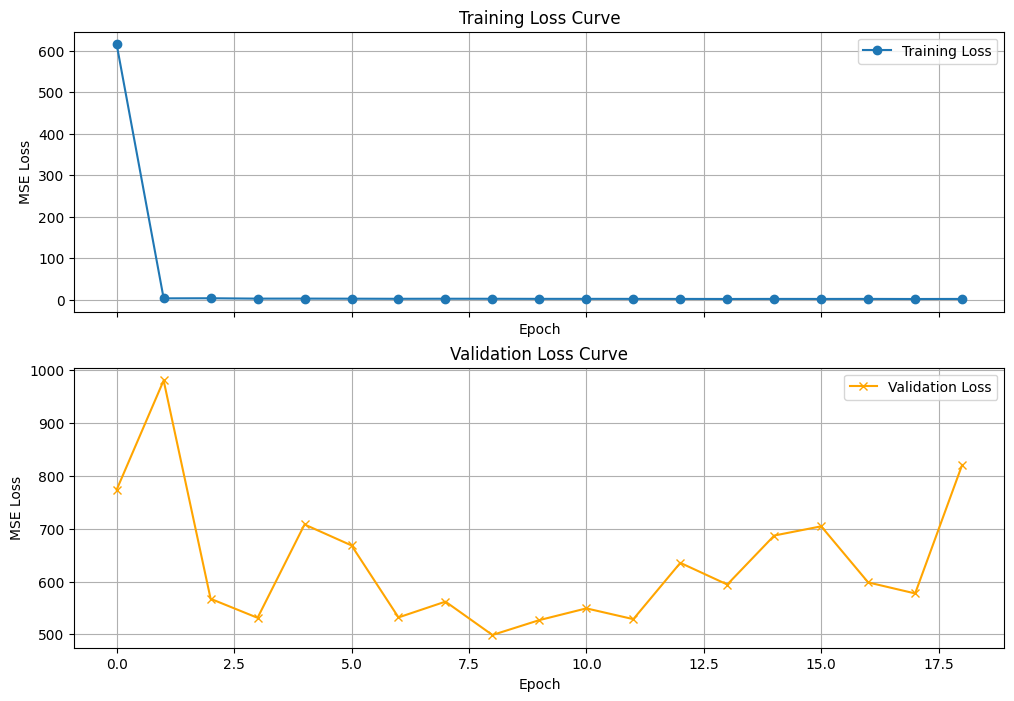

```python
def train_NBEATS(train_loader, val_loader, model, loss_func, optimizer, device, feature="prices"):
    num_epochs = 100
    train_losses = []
    val_losses = []
    best_val_loss = float('inf')
    patience = 10
    epochs_without_improve = 0

    if feature == "prices":
        save_path_best = "best_nbeats_price_model.pth"
        save_path_final = "nbeats_price_model_weights_final.pth"
    else:
        save_path_best = "best_nbeats_logr_model.pth"
        save_path_final = "nbeats_logr_model_weights_final.pth"

    for epoch in range(num_epochs):
        # Training loop
        model.train()
        running_train_loss = 0.0
        for inputs, targets in train_loader:
            inputs = inputs.to(device)   # shape: (batch_size, H*n)
            targets = targets.to(device)   # shape: (batch_size, H)

            optimizer.zero_grad()
            forecasts = model(inputs)      # forecast shape: (batch_size, H)
            loss = loss_func(forecasts, targets)
            loss.backward()
            optimizer.step()
            running_train_loss += loss.item() * inputs.size(0)

        epoch_train_loss = running_train_loss / len(train_loader.dataset)
        train_losses.append(epoch_train_loss)

        # Validation loop
        model.eval()
        running_val_loss = 0.0
        with torch.no_grad():
            for inputs, targets in val_loader:
                inputs = inputs.to(device)
                targets = targets.to(device)
                forecasts = model(inputs)
                loss = loss_func(forecasts, targets)
                running_val_loss += loss.item() * inputs.size(0)
        epoch_val_loss = running_val_loss / len(val_loader.dataset)
        val_losses.append(epoch_val_loss)

        print(f"Epoch {epoch+1}/{num_epochs} - Train Loss: {epoch_train_loss:.4f} - Val Loss: {epoch_val_loss:.4f}")

        # Early stopping: check if validation loss improved
        if epoch_val_loss < best_val_loss:
            best_val_loss = epoch_val_loss
            epochs_without_improve = 0
            # Optionally save the best model here
            torch.save(model.state_dict(), save_path_best)
            print(f"    Best model weights so far saved to {save_path_best}")
        else:
            epochs_without_improve += 1
            if epochs_without_improve >= patience:
                print(f"Early stopping triggered after {epoch+1} epochs.")
                break

    # Save the final model weights
    torch.save(model.state_dict(), save_path_final)
    print(f"    Final model weights saved to {save_path_final}")

    # Plot the training and validation loss curves
    fig, axs = plt.subplots(2, 1, figsize=(12, 8), sharex=True)
    axs[0].plot(train_losses, marker='o', label="Training Loss")
    axs[0].set_xlabel("Epoch")
    axs[0].set_ylabel("MSE Loss")
    axs[0].set_title("Training Loss Curve")
    axs[0].legend()
    axs[0].grid()

    axs[1].plot(val_losses, marker='x', color='orange', label="Validation Loss")
    axs[1].set_xlabel("Epoch")
    axs[1].set_ylabel("MSE Loss")
    axs[1].set_title("Validation Loss Curve")
    axs[1].legend()
    axs[1].grid()

train_NBEATS(train_loader, val_loader, model, loss_func, optimizer, device, feature="prices")
```

After finishing training, let us test the model using our test dataset, by loading the best training weights.

```
Using device: cuda
Loaded best model weights from best_nbeats_price_model.pth
X_test shape: torch.Size([691, 50])
Y_test shape: torch.Size([691, 10])
Test MSE Loss: 751.1787
```

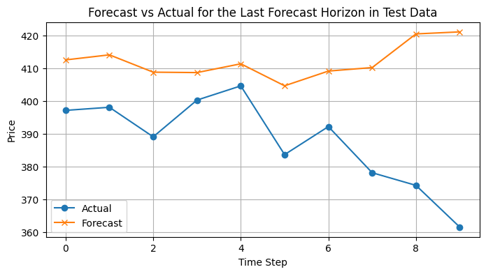

```python
H = 10  # forecast horizon
n = 5   # lookback multiplier
M = 3   # number of stacks
K = 30  # number of blocks per stack

# Check device
device = torch.device("cuda" if torch.cuda.is_available() else "cpu")
print("Using device:", device)

# Initialize the model architecture and load best weights
model = NBEATS(M, K, H, n).to(device)
model.load_state_dict(torch.load("best_nbeats_price_model.pth", map_location=device))
model.eval()
print("Loaded best model weights from best_nbeats_price_model.pth")

# Featurize the test series using the same H and n as training
test_series = test_data["Close"]
X_test, Y_test = featurize_series_NBEATS(test_series, H, n)
print("X_test shape:", X_test.shape)
print("Y_test shape:", Y_test.shape)

# Move test data to device (we'll work on the whole tensor here for simplicity)
X_test = X_test.to(device)
Y_test = Y_test.to(device)

# Compute forecasts on the test set
with torch.no_grad():
    forecasts_test = model(X_test)  # shape: (num_samples, H)

# Compute test loss (MSE)
test_loss = nn.MSELoss()(forecasts_test, Y_test).item()
print(f"Test MSE Loss: {test_loss:.4f}")

# For visualization, let's plot the last forecast sample:
# We'll take the last sample from the test set, which corresponds to the last available forecast horizon.
last_forecast = forecasts_test[-1].cpu().numpy()
last_target = Y_test[-1].cpu().numpy()

plt.figure(figsize=(8, 4))
plt.plot(range(H), last_target, marker='o', label="Actual")
plt.plot(range(H), last_forecast, marker='x', label="Forecast")
plt.xlabel("Time Step")
plt.ylabel("Price")
plt.title("Forecast vs Actual for the Last Forecast Horizon in Test Data")
plt.legend()
plt.grid(True)
plt.show()
```

After our test results, we apply all of the above steps for the log returns dataset also.

```
X_logr shape: torch.Size([2457, 50])
Y_logr shape: torch.Size([2457, 10])
Using device: cuda
    Best model weights so far saved to best_nbeats_logr_model.pth
    Best model weights so far saved to best_nbeats_logr_model.pth
    Best model weights so far saved to best_nbeats_logr_model.pth
    Best model weights so far saved to best_nbeats_logr_model.pth
    Best model weights so far saved to best_nbeats_logr_model.pth
Early stopping triggered after 34 epochs.
    Final model weights saved to nbeats_logr_model_weights_final.pth
```

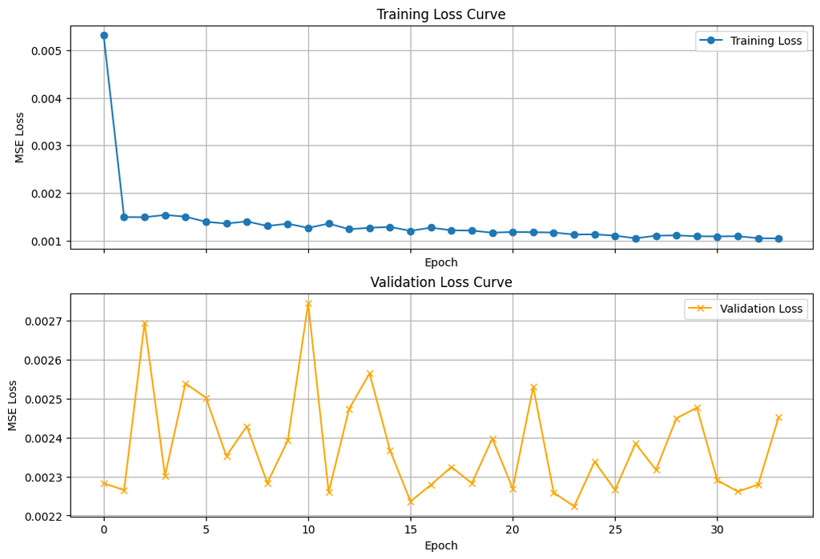

```python
logr_series = trainval_data["logr"]

# Featurize the log returns series
X_logr, Y_logr = featurize_series_NBEATS(logr_series, H, n)
print("X_logr shape:", X_logr.shape)
print("Y_logr shape:", Y_logr.shape)

# Split into training and validation sets
X_train_logr, Y_train_logr, X_val_logr, Y_val_logr = train_val_split(X_logr, Y_logr, val_size=0.2)

# Create DataLoaders
batch_size = 32
train_dataset_logr = TensorDataset(X_train_logr, Y_train_logr)
val_dataset_logr = TensorDataset(X_val_logr, Y_val_logr)

train_loader_logr = DataLoader(train_dataset_logr, batch_size=batch_size, shuffle=True)
val_loader_logr   = DataLoader(val_dataset_logr, batch_size=batch_size, shuffle=False)

# Check for GPU
device = torch.device("cuda" if torch.cuda.is_available() else "cpu")
print("Using device:", device)

M = 3 # Number of stacks in the network
K = 30  # Number of blocks in the stack
H = 10  # Forecast horizon
n = 5  # Look back n times the forecast horizon

# Initialize model
model = NBEATS(M, K, H, n).to(device)

# Choose loss function and optimizer
loss_func = nn.MSELoss()
optimizer = torch.optim.Adam(model.parameters(), lr=0.0001)

# Call training function with feature="logr"
train_NBEATS(train_loader_logr, val_loader_logr, model, loss_func, optimizer, device, feature="logr")
```

```
X_frac shape: torch.Size([2457, 50])
Y_frac shape: torch.Size([2457, 10])
Using device: cuda
    Best model weights so far saved to best_nbeats_logr_model.pth
Early stopping triggered after 11 epochs.
    Final model weights saved to nbeats_logr_model_weights_final.pth
```

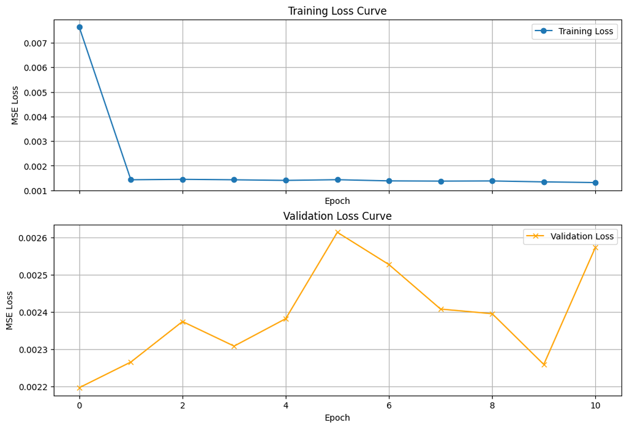

```python
# Featurize the fractionalized series
X_frac, Y_frac = featurize_series_NBEATS(frac_prices, H, n)
print("X_frac shape:", X_logr.shape)
print("Y_frac shape:", Y_logr.shape)

# Split into training and validation sets
X_train_frac, Y_train_frac, X_val_frac, Y_val_frac = train_val_split(X_frac, Y_frac, val_size=0.2)

# Create DataLoaders
batch_size = 32
train_dataset_frac = TensorDataset(X_train_frac, Y_train_frac)
val_dataset_frac = TensorDataset(X_val_frac, Y_val_frac)

train_loader_frac = DataLoader(train_dataset_frac, batch_size=batch_size, shuffle=True)
val_loader_frac   = DataLoader(val_dataset_frac, batch_size=batch_size, shuffle=False)

# Check for GPU
device = torch.device("cuda" if torch.cuda.is_available() else "cpu")
print("Using device:", device)

M = 3 # Number of stacks in the network
K = 30  # Number of blocks in the stack
H = 10  # Forecast horizon
n = 5  # Look back n times the forecast horizon

# Initialize model
model = NBEATS(M, K, H, n).to(device)

# Choose loss function and optimizer
loss_func = nn.MSELoss()
optimizer = torch.optim.Adam(model.parameters(), lr=0.0001)

# Call training function with feature="logr"
train_NBEATS(train_loader_logr, val_loader_logr, model, loss_func, optimizer, device, feature="logr")
```

## Step 3

Still let's get the data of *TSLA* from 2022-02-10 to 2025-02-10.

```python
import numpy as np
import pandas as pd
from matplotlib import pyplot as plt
import yfinance as yf
from datetime import date, timedelta
import statsmodels
import scipy.stats as stats
import torch
from torch import nn
import torchinfo
from pyts.image import GramianAngularField
from torch.utils.data import TensorDataset, DataLoader
import time
```

```python
start_date = date(2012, 2, 10)
# end_date = date(2022, 2, 10)
# start_date = date(2022, 2, 10)
end_date = date(2025, 2, 10)

end_date = date(2025, 2, 10)
start_date = date(2022, 2, 10)

ticker = "TSLA"

tsla_data = yf.download(ticker, start_date, end_date, auto_adjust=False, progress=False)
tsla_data.columns = [x[0] for x in tsla_data.columns]
tsla_data = tsla_data[['Adj Close']]
tsla_logr = tsla_data[['Adj Close']].apply(np.log).diff()
```

```python
tsla_logr.head()
```

| Date | Adj Close |
| --- | --- |
| 2022-02-10 | NaN |
| 2022-02-11 | -0.050505 |
| 2022-02-14 | 0.018160 |
| 2022-02-15 | 0.051919 |
| 2022-02-16 | 0.001040 |

Log returns and fractional diffrencing are calculated as before. Truncations are done for the original stock prices and log returns so that all 3 time series have the same length.

```python
def getWeights(d,lags):
    # return the weights from the series expansion of the differencing operator
    # for real orders d and up to lags coefficients
    w=[1]
    for k in range(1,lags):
        w.append(-w[-1]*((d-k+1))/k)
    w=np.array(w).reshape(-1,1)
    return w

def ts_differencing(series, order, lag_cutoff):
    # return the time series resulting from (fractional) differencing
    # for real orders order up to lag_cutoff coefficients

    weights=getWeights(order, lag_cutoff)
    res=0
    for k in range(lag_cutoff):
        res += weights[k]*series.shift(k).fillna(0)
    return res[lag_cutoff:]

tsla_frac = ts_differencing(tsla_data[["Adj Close"]], 0.5, 10)


tsla_data = tsla_data[10:]
tsla_logr = tsla_logr[10:]
```

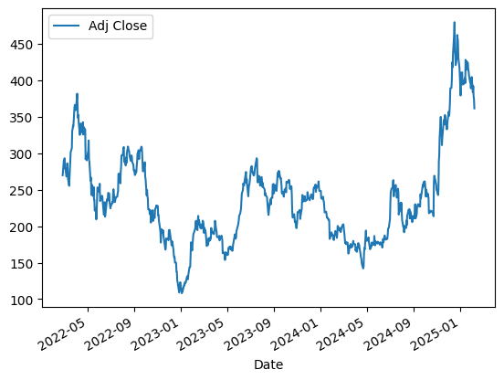

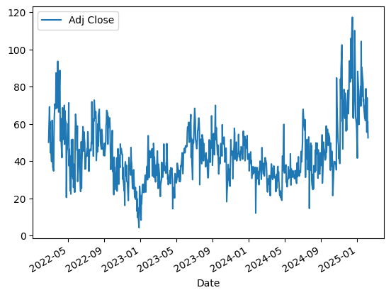

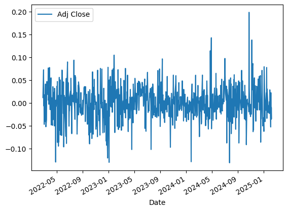

```python
tsla_data.plot()
tsla_frac.plot()
tsla_logr.plot()
```

Window size is set as 60. That is to say, we will predict the value based on data of the previous 60 days (2 months), which will go through Gramian Angular Field transformation before being fed to our models.

```python
window_size = 60
transformer = GramianAngularField()
```

```python
X_orig, y_orig = [], []
X_logr, y_logr= [], []
X_frac, y_frac = [], []

for i in range(len(tsla_data) - window_size):
    X_orig.append(transformer.transform(tsla_data['Adj Close'].iloc[i:i + window_size].values.reshape(1, -1)))  # Past 50 days
    y_orig.append(tsla_data['Adj Close'].iloc[i + window_size])  # Next day

    X_logr.append(transformer.transform(tsla_logr['Adj Close'].iloc[i:i + window_size].values.reshape(1, -1)))  # Past 50 days
    y_logr.append(tsla_logr['Adj Close'].iloc[i + window_size])  # Next day

    X_frac.append(transformer.transform(tsla_frac['Adj Close'].iloc[i:i + window_size].values.reshape(1, -1)))  # Past 50 days
    y_frac.append(tsla_frac['Adj Close'].iloc[i + window_size])  # Next day

# Convert to numpy arrays for modeling
X_orig = torch.Tensor(np.array(X_orig))
y_orig = torch.Tensor(np.array(y_orig))

X_logr = torch.Tensor(np.array(X_logr))
y_logr = torch.Tensor(np.array(y_logr))

X_frac = torch.Tensor(np.array(X_frac))
y_frac = torch.Tensor(np.array(y_frac))

print(f"Shape of X_orig: {X_orig.shape}")  # (num_samples, 30)
print(f"Shape of y_orig: {y_orig.shape}")  # (num_samples,)

print(f"Shape of X_frac: {X_frac.shape}")  # (num_samples, 30)
print(f"Shape of y_frac: {y_frac.shape}")  # (num_samples,)

print(f"Shape of X_logr: {X_logr.shape}")  # (num_samples, 30)
print(f"Shape of y_logr: {y_logr.shape}")  # (num_samples,)
```

```
Shape of X_orig: torch.Size([681, 1, 60, 60])
Shape of y_orig: torch.Size([681])
Shape of X_frac: torch.Size([681, 1, 60, 60])
Shape of y_frac: torch.Size([681])
Shape of X_logr: torch.Size([681, 1, 60, 60])
Shape of y_logr: torch.Size([681])
```

The data is splitted into train, validation and test with size 0.8, 0.1, 0.1

```python
train_size = int(0.8 * len(X_orig))
val_size = int(0.9 * len(X_orig))

X_orig_train, X_orig_val, X_orig_test, y_orig_train, y_orig_val, y_orig_test \
    = X_orig[:train_size], X_orig[train_size+1:val_size], X_orig[val_size+1:], y_orig[:train_size], y_orig[train_size+1:val_size], y_orig[val_size+1:]

X_frac_train, X_frac_val, X_frac_test, y_frac_train, y_frac_val, y_frac_test \
    = X_frac[:train_size], X_frac[train_size+1:val_size], X_frac[val_size+1:], y_frac[:train_size], y_frac[train_size+1:val_size], y_frac[val_size+1:]

X_logr_train, X_logr_val, X_logr_test, y_logr_train, y_logr_val, y_logr_test \
    = X_logr[:train_size], X_logr[train_size+1:val_size], X_logr[val_size+1:], y_logr[:train_size], y_logr[train_size+1:val_size], y_logr[val_size+1:]
```

```python
batch_size = 12
test_size = len(X_logr_test)
print(test_size)
```

```
68
```

```python
len(X_orig), len(X_frac)
```

```
(681, 681)
```

```python
print(X_logr_train.shape, X_logr_val.shape, X_logr_test.shape)
```

```
torch.Size([544, 1, 60, 60]) torch.Size([67, 1, 60, 60]) torch.Size([68, 1, 60, 60])
```

Dataset and Dataloader preparation.

```python
orig_train_dataset = TensorDataset(X_orig_train, y_orig_train)
orig_val_dataset   = TensorDataset(X_orig_val, y_orig_val)
# orig_test_dataset  = TensorDataset(X_orig_test, y_orig_test)

logr_train_dataset = TensorDataset(X_logr_train, y_logr_train)
logr_val_dataset   = TensorDataset(X_logr_val, y_logr_val)
# logr_test_dataset  = TensorDataset(X_logr_test, y_logr_test)

frac_train_dataset = TensorDataset(X_frac_train, y_frac_train)
frac_val_dataset   = TensorDataset(X_frac_val, y_frac_val)
# frac_test_dataset  = TensorDataset(X_frac_test, y_frac_test)

orig_train_loader = DataLoader(orig_train_dataset, batch_size=batch_size, shuffle=True)
orig_val_loader   = DataLoader(orig_val_dataset, batch_size=batch_size, shuffle=False)
# orig_test_loader   = DataLoader(orig_test_dataset, batch_size=batch_size, shuffle=False)

frac_train_loader = DataLoader(frac_train_dataset, batch_size=batch_size, shuffle=True)
frac_val_loader   = DataLoader(frac_val_dataset, batch_size=batch_size, shuffle=False)
# frac_test_loader   = DataLoader(frac_test_dataset, batch_size=batch_size, shuffle=False)

logr_train_loader = DataLoader(logr_train_dataset, batch_size=batch_size, shuffle=True)
logr_val_loader   = DataLoader(logr_val_dataset, batch_size=batch_size, shuffle=False)
# logr_test_loader   = DataLoader(logr_test_dataset, batch_size=batch_size, shuffle=False)
```

The neural network is a vanilla convolutional one with the top being $\tanh$ and linear ones.

```python
class FCN(nn.Module):

    def __init__(self):
        super().__init__()
        self.conv1   = nn.Conv2d(1, 3, kernel_size=3, stride=2, padding=1, dilation=1)
        self.bnd1    = nn.BatchNorm2d(3)
        self.conv2   = nn.Conv2d(3, 5, kernel_size=3, stride=2, padding=1, dilation=1)
        self.bnd2    = nn.BatchNorm2d(5)
        self.conv3   = nn.Conv2d(5, 8, kernel_size=3, stride=2, padding=1, dilation=1)
        self.bnd3    = nn.BatchNorm2d(8)
        self.conv4   = nn.Conv2d(8, 12, kernel_size=3, stride=2, padding=1, dilation=1)
        self.bnd4    = nn.BatchNorm2d(12)
        self.conv5   = nn.Conv2d(12, 20, kernel_size=3, stride=2, padding=1, dilation=1)
        self.bnd5    = nn.BatchNorm2d(20)
        self.relu    = nn.ReLU(inplace=True)
        self.flatten = nn.Flatten()
        self.linear1 = nn.Linear(in_features=80, out_features=20)
        self.tanh    = nn.Tanh()
        self.linear2 = nn.Linear(in_features=20, out_features=1)


    def forward(self, x):
        x = self.bnd1(self.relu(self.conv1(x)))
        x = self.bnd2(self.relu(self.conv2(x)))
        x = self.bnd3(self.relu(self.conv3(x)))
        x = self.bnd4(self.relu(self.conv4(x)))
        x = self.bnd5(self.relu(self.conv5(x)))
        x = self.flatten(x)
        # print(x.shape)
        x = self.linear1(x)
        x = self.tanh(x)
        x = self.linear2(x)
        return x
```

Use GPU if available, and initialize weights with Xavier and normal.

```python
if torch.cuda.is_available():
    device = torch.device('cuda')
elif torch.backends.mps.is_available():
    device = torch.device('mps')
else:
    device = torch.device('cpu')


def init_weights(m):
    if isinstance(m, nn.Conv2d) or isinstance(m, nn.Linear):
        torch.nn.init.xavier_uniform_(m.weight.data)
        torch.nn.init.normal_(m.bias.data) #xavier not applicable for biases
```

```python
model_orig, model_frac, model_logr = FCN(), FCN(), FCN()

model_orig = model_orig.to(device)
model_frac = model_frac.to(device)
model_logr = model_logr.to(device)

model_orig.apply(init_weights);
model_frac.apply(init_weights);
model_logr.apply(init_weights);
```

Prepare the function that can plot epoch vs losses.

```python
def BasicPlot(y, file_name='noname.png',x_text = "", y_text="", title_text="",colour='blue', scale=1, x_shift=0):
    plt.figure();
    x=np.array(range(len(y)))+1+x_shift;  x*=scale;
    # print(len(x));
    plt.plot(x,y,color=colour,linewidth=0.8);
    plt.xlabel(x_text);
    plt.ylabel(y_text);
    plt.title(title_text);
    plt.savefig(file_name, bbox_inches='tight');
    plt.show()
```

Functions that validate and train models.

```
Epoch: 0
epoch0, iter0, number of data points: 12, mean loss: 4853.874348958333
epoch0, iter10, number of data points: 12, mean loss: 4360.729166666667
epoch0, iter20, number of data points: 12, mean loss: 3607.9781901041665
epoch0, iter30, number of data points: 12, mean loss: 4396.855143229167
epoch0, iter40, number of data points: 12, mean loss: 4185.501953125

Validation loss is 4516.056728078358
Finish epoch 0, time elapsed 0.4224588871002197



Epoch: 1
epoch1, iter0, number of data points: 12, mean loss: 3062.0436197916665
epoch1, iter10, number of data points: 12, mean loss: 3822.728515625
epoch1, iter20, number of data points: 12, mean loss: 3381.69921875
epoch1, iter30, number of data points: 12, mean loss: 4101.403645833333
epoch1, iter40, number of data points: 12, mean loss: 4267.377604166667

Validation loss is 4430.457555970149
Finish epoch 1, time elapsed 0.08076262474060059



Epoch: 2
epoch2, iter0, number of data points: 12, mean loss: 4303.882486979167
epoch2, iter10, number of data points: 12, mean loss: 3989.0543619791665
epoch2, iter20, number of data points: 12, mean loss: 3507.8089192708335
epoch2, iter30, number of data points: 12, mean loss: 4319.424153645833
epoch2, iter40, number of data points: 12, mean loss: 3314.0201822916665

Validation loss is 4376.820020988806
Finish epoch 2, time elapsed 0.08216214179992676



Epoch: 3
epoch3, iter0, number of data points: 12, mean loss: 3420.951171875
epoch3, iter10, number of data points: 12, mean loss: 3622.7317708333335
epoch3, iter20, number of data points: 12, mean loss: 3870.5139973958335
```

[output cut: 3590 more lines]

```

Validation loss is 35.84969045155084
Finish epoch 302, time elapsed 0.07932782173156738



Epoch: 303
epoch303, iter0, number of data points: 12, mean loss: 39.75562286376953
epoch303, iter10, number of data points: 12, mean loss: 6.544169743855794
epoch303, iter20, number of data points: 12, mean loss: 97.39151000976562
epoch303, iter30, number of data points: 12, mean loss: 49.41348775227865
epoch303, iter40, number of data points: 12, mean loss: 53.923797607421875

Validation loss is 33.57895853982043
Early stopping triggered after 304 epochs.
```

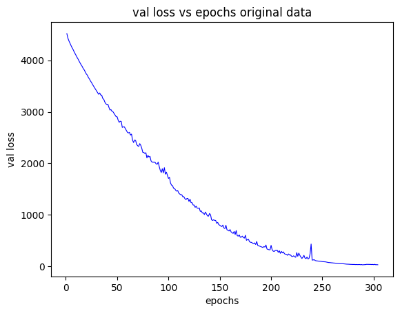

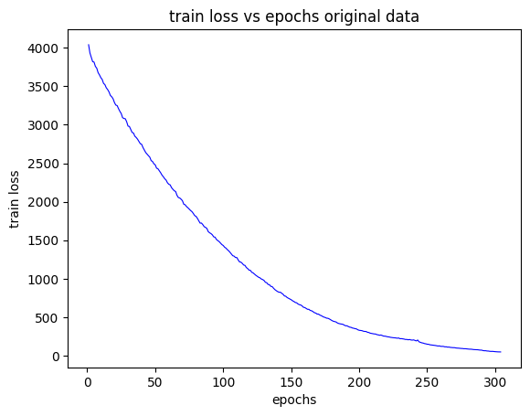

```python
def val_models(val_loader, cnn_model, loss_func, optimizer, device):
    losses = []
    best_val_loss = float('inf')
    cnn_model.eval()
    total = 0
    with torch.no_grad():
        for iter, (inputs, targets) in enumerate(val_loader):
            optimizer.zero_grad()
            inputs = inputs.to(device)
            targets = targets.to(device)

            outputs = cnn_model(inputs)
            outputs = outputs.float().squeeze(axis=1)

            loss = loss_func(outputs, targets)
            losses.append(loss.item())

            total += len(inputs)

    mean_loss = np.sum(losses) / len(val_loader.dataset)
    cnn_model.train()
    return mean_loss

def train_models(train_loader, val_loader, cnn_model, loss_func, optimizer, device, \
                 model_save_path = "val_loss.pth", plot_save_path = 'pic.png', epochs = 50, patience = 0, tname = ''):

    train_losses = []
    current_train_loss = 0
    val_losses = []
    best_val_loss = float('inf')
    cnn_model.train()
    epochs_without_improve = 0

    for epoch in range(epochs):
        ts = time.time(); print();
        print('Epoch: {}'.format(epoch))
        current_train_loss = 0
        for iter, (inputs, targets) in enumerate(train_loader):
            optimizer.zero_grad()
            inputs = inputs.to(device)
            targets = targets.to(device)

            targets = targets.float()

            outputs = cnn_model(inputs)
            outputs = outputs.float().squeeze(axis=1)

            # print(outputs.shape, targets.shape)
            loss = loss_func(outputs, targets)

            loss.backward()
            optimizer.step()
            current_train_loss += loss.item()

            if iter % 10 == 0:
                print("epoch{}, iter{}, number of data points: {}, mean loss: {}".format(epoch, iter, len(inputs), loss.item() / len(inputs)))

        train_losses.append(current_train_loss / len(train_loader.dataset))

        val_loss = val_models(val_loader, cnn_model, loss_func, optimizer, device)

        val_losses.append(val_loss)
        print()
        print('Validation loss is {}'.format(val_loss))

        if patience > 0:
            if val_loss < best_val_loss:
                best_val_loss = val_loss
                epochs_without_improve = 0
                torch.save(cnn_model.state_dict(), model_save_path)
            else:
                epochs_without_improve += 1
                if epochs_without_improve >= patience:
                    print(f"Early stopping triggered after {epoch+1} epochs.")
                    break

        print("Finish epoch {}, time elapsed {}".format(epoch, time.time() - ts))
        print('\n')
    BasicPlot(val_losses, plot_save_path + '_val.png', 'epochs', 'val loss', 'val loss vs epochs' + tname)
    BasicPlot(train_losses, plot_save_path + '_train.png', 'epochs', 'train loss', 'train loss vs epochs' + tname)

    return cnn_model

loss_func = nn.MSELoss()
optimizer_orig = torch.optim.Adam(model_orig.parameters(), lr=0.001)
optimizer_frac = torch.optim.Adam(model_orig.parameters(), lr=0.001)
optimizer_logr = torch.optim.Adam(model_orig.parameters(), lr=0.001)

train_models(orig_train_loader, orig_val_loader, model_orig, loss_func, optimizer_orig, device, \
                 model_save_path = "orig_model.pth", plot_save_path = 'orig_model', epochs = 1200, patience = 15, tname = ' original data');
```

```
Epoch: 0
epoch0, iter0, number of data points: 12, mean loss: 154.78507486979166
epoch0, iter10, number of data points: 12, mean loss: 127.82045491536458
epoch0, iter20, number of data points: 12, mean loss: 159.06075032552084
epoch0, iter30, number of data points: 12, mean loss: 138.02840169270834
epoch0, iter40, number of data points: 12, mean loss: 142.11979166666666

Validation loss is 182.73463736007463
Finish epoch 0, time elapsed 0.13731074333190918



Epoch: 1
epoch1, iter0, number of data points: 12, mean loss: 144.8290812174479
epoch1, iter10, number of data points: 12, mean loss: 132.72078450520834
epoch1, iter20, number of data points: 12, mean loss: 160.42643229166666
epoch1, iter30, number of data points: 12, mean loss: 177.86834716796875
epoch1, iter40, number of data points: 12, mean loss: 124.70751953125

Validation loss is 184.60619388409515
Finish epoch 1, time elapsed 0.10114932060241699



Epoch: 2
epoch2, iter0, number of data points: 12, mean loss: 123.3135477701823
epoch2, iter10, number of data points: 12, mean loss: 168.9801025390625
epoch2, iter20, number of data points: 12, mean loss: 180.3622029622396
epoch2, iter30, number of data points: 12, mean loss: 155.1640625
epoch2, iter40, number of data points: 12, mean loss: 159.89509073893228

Validation loss is 185.11480621793376
Finish epoch 2, time elapsed 0.11667442321777344



Epoch: 3
epoch3, iter0, number of data points: 12, mean loss: 176.89217122395834
epoch3, iter10, number of data points: 12, mean loss: 179.657470703125
epoch3, iter20, number of data points: 12, mean loss: 118.94778442382812
```

[output cut: 134 more lines]

```

Validation loss is 184.9657419688666
Finish epoch 14, time elapsed 0.06959939002990723



Epoch: 15
epoch15, iter0, number of data points: 12, mean loss: 121.16014607747395
epoch15, iter10, number of data points: 12, mean loss: 165.32782999674478
epoch15, iter20, number of data points: 12, mean loss: 120.57278442382812
epoch15, iter30, number of data points: 12, mean loss: 126.154541015625
epoch15, iter40, number of data points: 12, mean loss: 176.4522705078125

Validation loss is 184.6171966097248
Early stopping triggered after 16 epochs.
```

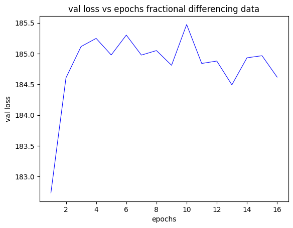

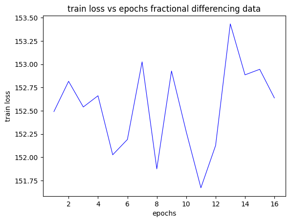

```python
train_models(frac_train_loader, frac_val_loader, model_frac, loss_func, optimizer_frac, device, \
                 model_save_path = "frac_model.pth", plot_save_path = 'frac_model.png', epochs = 1200, patience = 15, tname = ' fractional differencing data');
```

```
Epoch: 0
epoch0, iter0, number of data points: 12, mean loss: 0.016733407974243164
epoch0, iter10, number of data points: 12, mean loss: 0.02424376706282298
epoch0, iter20, number of data points: 12, mean loss: 0.028517643610636394
epoch0, iter30, number of data points: 12, mean loss: 0.029612685243288677
epoch0, iter40, number of data points: 12, mean loss: 0.05305404464403788

Validation loss is 0.018358460557994557
Finish epoch 0, time elapsed 0.08600664138793945



Epoch: 1
epoch1, iter0, number of data points: 12, mean loss: 0.027581006288528442
epoch1, iter10, number of data points: 12, mean loss: 0.03832821796337763
epoch1, iter20, number of data points: 12, mean loss: 0.04186944663524628
epoch1, iter30, number of data points: 12, mean loss: 0.044102360804875694
epoch1, iter40, number of data points: 12, mean loss: 0.029099846879641216

Validation loss is 0.053137282382196456
Finish epoch 1, time elapsed 0.07751989364624023



Epoch: 2
epoch2, iter0, number of data points: 12, mean loss: 0.0442663828531901
epoch2, iter10, number of data points: 12, mean loss: 0.03853177030881246
epoch2, iter20, number of data points: 12, mean loss: 0.027350907524426777
epoch2, iter30, number of data points: 12, mean loss: 0.0957878331343333
epoch2, iter40, number of data points: 12, mean loss: 0.05475748578707377

Validation loss is 0.049242903047533176
Finish epoch 2, time elapsed 0.08158564567565918



Epoch: 3
epoch3, iter0, number of data points: 12, mean loss: 0.03256805241107941
epoch3, iter10, number of data points: 12, mean loss: 0.029350693027178448
epoch3, iter20, number of data points: 12, mean loss: 0.04419983923435211
```

[output cut: 134 more lines]

```

Validation loss is 0.043795916793951346
Finish epoch 14, time elapsed 0.06842398643493652



Epoch: 15
epoch15, iter0, number of data points: 12, mean loss: 0.013788379728794098
epoch15, iter10, number of data points: 12, mean loss: 0.09475451707839966
epoch15, iter20, number of data points: 12, mean loss: 0.044948309659957886
epoch15, iter30, number of data points: 12, mean loss: 0.042159135142962136
epoch15, iter40, number of data points: 12, mean loss: 0.026023196677366894

Validation loss is 0.055001110839309975
Early stopping triggered after 16 epochs.
```

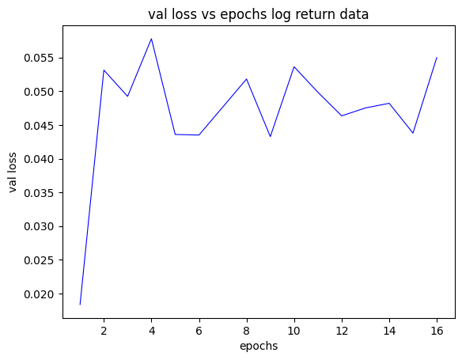

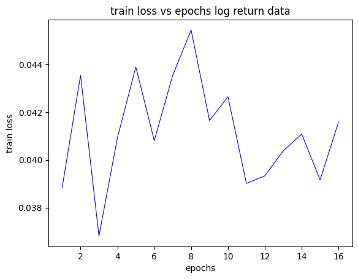

```python
train_models(logr_train_loader, logr_val_loader, model_logr, loss_func, optimizer_logr, device, \
                 model_save_path = "logr_model.pth", plot_save_path = 'logr_model.png', epochs = 1200, patience = 15, tname = ' log return data');
```

Notice, those losses are of different scales, because original stock prices, log returns and fractional differencing are of totally different scales. Hence judgments cannot be made based on the absolute values of losses, but on by how much the losses decreased.

It seems that the training of original stock prices is decent and the other 2 are poor.

Now compare predictions and the real data.

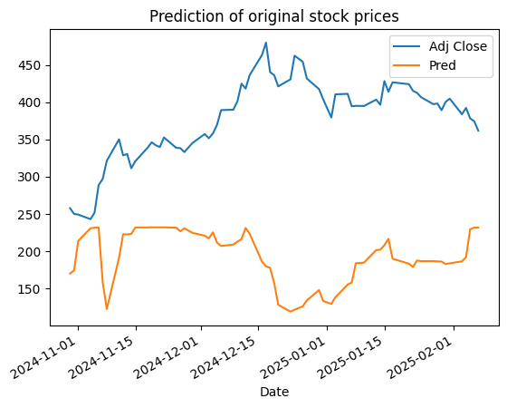

```python
orig_test_pred = model_orig(X_orig_test.to(device))
tsla_data_pred = tsla_data[-test_size:]
tsla_data_pred['Pred'] = orig_test_pred.to('cpu').detach().numpy()
tsla_data_pred.plot();
plt.title('Prediction of original stock prices');
```

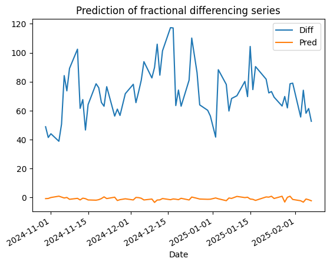

```python
frac_test_pred = model_frac(X_frac_test.to(device))
tsla_frac_pred = tsla_frac[-test_size:]
tsla_frac_pred['Pred'] = frac_test_pred.to('cpu').detach().numpy()
tsla_frac_pred.columns = ('Diff', 'Pred')
tsla_frac_pred.plot();
plt.title('Prediction of fractional differencing series');
```

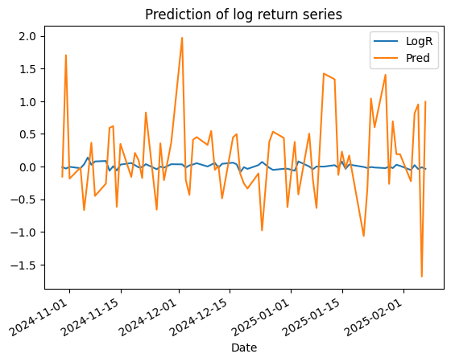

```python
logr_test_pred = model_logr(X_logr_test.to(device))
tsla_logr_pred = tsla_logr[-test_size:]
tsla_logr_pred['Pred'] = logr_test_pred.to('cpu').detach().numpy()
tsla_logr_pred.columns = ('LogR', 'Pred')
tsla_logr_pred.plot();
plt.title('Prediction of log return series')
```